# Final Examination ECON7960 User Experience and AB Test

# It is based on a data analytic competition

## Problem Statement

In this exercise https://www.kaggle.com/c/ga-customer-revenue-prediction , the aim is to analyze a Google Merchandise Store (also known as GStore, where Google swag is sold) customer dataset to predict purchase likelihood of the customer. The exercise here is an exposition of the data and look into the Google Analytics (GA) data about the personas of the visitors and the analysis might lead to a better use of marketing budgets for those companies who choose to use data analysis on top of GA data.

Both data files "learn.csv" and "verify.csv" are converted from the JSON format data usually collected over webs, mobile applications and IoT log files which can easily be imported into a python data framework for analysis. It is also essential to apply data processing steps to clear the data file for the analysis.

## Requirements:

Students are required to use suggested tools to help to extract the most important factor determining the above business objective. You should have experience in Workshop 4 and Quiz 2 that enable you to work with the data file "learn.csv" for analysis.

Please make sure your write down your answer in this file using "markdown" like the following

## Questions

Q1: Separate visitors who stay to purchase, who do not. (Make your own definition on potential purchaser) – 10%

Q2: Seek out insights of the personas of the visitors who are potential purchasers (defined in Q1) in the "learn.csv" – 30%

Q3: Using 3 different kinds of algorithms or methods to determine the most importance factors to predict the potential purchaser by divided the file "learn.csv" into train file and test file, please brief describe each algorithm – 30%

Q4. Given your findings, how you would suggest attracting more potential purchasers to the GStore based on decision model taught in the course – 30%

OR

Q4. Based on the “most” important feature (rank one) of the potential purchaser you find, use the dataset "verify.csv" of 10000 sample customers (not the data you used for Q1-Q3) to conduct an AB test on that single feature – 30%

The total mark of the project is 30% of the course grade. Evaluation based on your efficient code, your description on how to approach the problem and the explanation about steps taken to address the issue.

As the first step, lets load the required libraries.

```python
import datetime as dt
import numpy as np
import pandas as pd
import json
from pandas.io.json import json_normalize
import seaborn as sns
import matplotlib.pyplot as plt
from plotly.offline import init_notebook_mode, iplot
import plotly.graph_objs as go
from plotly import tools
init_notebook_mode(connected=True)
```

If your PC does not have plotly, you need to find way to install plotly to call in init_notebook_mode, iplot, plotly.graph_objs and tools

## 2. Understanding the Dataset

The data is shared in csv format. The csv files contains some filed with json objects. The description about dataset fields is given https://www.kaggle.com/c/ga-customer-revenue-prediction/data

### 2.1 Dataset Preparation

Lets read the dataset in csv format after dealing with json transformation in associated file _data.ipynb

```python
# read in data
train = pd.read_csv('../input/finalexam/learn.csv')
```

### 2.2 Dataset Snapshot

Lets view the snapshot of the test dataset.

```python
print ("There are " + str(train.shape[0]) + " rows and " + str(train.shape[1]) + " raw columns in this dataset")
```

```
There are 20000 rows and 57 raw columns in this dataset
```

```python
train.head()
```

|  | channelGrouping | date | fullVisitorId | socialEngagementType | visitId | visitNumber | visitStartTime | device.browser | device.browserVersion | device.browserSize | ... | trafficSource.medium | trafficSource.keyword | trafficSource.adContent | trafficSource.isTrueDirect | trafficSource.adwordsClickInfo.criteriaParameters | trafficSource.adwordsClickInfo.page | trafficSource.adwordsClickInfo.slot | trafficSource.adwordsClickInfo.gclId | trafficSource.adwordsClickInfo.adNetworkType | trafficSource.adwordsClickInfo.isVideoAd |
| --- | --- | --- | --- | --- | --- | --- | --- | --- | --- | --- | --- | --- | --- | --- | --- | --- | --- | --- | --- | --- | --- |
| 0 | Organic Search | 20180511 | 7460955084541987166 | Not Socially Engaged | 1526099341 | 2 | 1526099341 | Chrome | not available in demo dataset | not available in demo dataset | ... | organic | (not provided) | (not set) | True | not available in demo dataset | NaN | NaN | NaN | NaN | NaN |
| 1 | Direct | 20180511 | 460252456180441002 | Not Socially Engaged | 1526064483 | 166 | 1526064483 | Chrome | not available in demo dataset | not available in demo dataset | ... | (none) | (not set) | (not set) | True | not available in demo dataset | NaN | NaN | NaN | NaN | NaN |
| 2 | Organic Search | 20180511 | 3461808543879602873 | Not Socially Engaged | 1526067157 | 2 | 1526067157 | Chrome | not available in demo dataset | not available in demo dataset | ... | organic | (not provided) | (not set) | True | not available in demo dataset | NaN | NaN | NaN | NaN | NaN |
| 3 | Direct | 20180511 | 975129477712150630 | Not Socially Engaged | 1526107551 | 4 | 1526107551 | Chrome | not available in demo dataset | not available in demo dataset | ... | (none) | (not set) | (not set) | True | not available in demo dataset | NaN | NaN | NaN | NaN | NaN |
| 4 | Organic Search | 20180511 | 8381672768065729990 | Not Socially Engaged | 1526060254 | 1 | 1526060254 | Internet Explorer | not available in demo dataset | not available in demo dataset | ... | organic | (not provided) | (not set) | NaN | not available in demo dataset | NaN | NaN | NaN | NaN | NaN |

5 rows × 57 columns

### 2.3 Missing Values Percentage

From the above snapshot we can observe that there are many missing values in the dataset.

```python
miss_per = {}
for k, v in dict(train.isna().sum(axis=0)).items():
    if v == 0:
        continue
    miss_per[k] = 100 * float(v) / len(train)

import operator
sorted_x = sorted(miss_per.items(), key=operator.itemgetter(1), reverse=True)
print ("There are " + str(len(miss_per)) + " columns with missing values")

kys = [_[0] for _ in sorted_x][::-1]
vls = [_[1] for _ in sorted_x][::-1]
trace1 = go.Bar(y = kys, orientation="h" , x = vls, marker=dict(color="#d6a5ff"))
layout = go.Layout(title="Missing Values Percentage",
                   xaxis=dict(title="Missing Percentage"),
                   height=400, margin=dict(l=300, r=300))
figure = go.Figure(data = [trace1], layout = layout)
iplot(figure)
```

```
There are 14 columns with missing values
```

[interactive chart not shown]

> - So we can observe that there are some columns in the dataset having very large number of missing values.

##### Drop over 97% missing observation variables except the crucial target variables

```python
train = train.drop(['trafficSource.adwordsClickInfo.page', 'trafficSource.adwordsClickInfo.slot',
                    'trafficSource.adwordsClickInfo.gclId', 'trafficSource.adwordsClickInfo.adNetworkType',
       'trafficSource.adwordsClickInfo.isVideoAd'], axis = 1)
```

## 3. Visitor Profile

##### Lets create the visitor profile for different features of an average customer. But first fill the missing observations with zero.

### 3.1 General Visitor Profile Snapshot

```python
# import pandas_profiling as pdf
# from pathlib import Path
# profile1 = pdf.ProfileReport(train,
#                              title='Annex 1 Google Shop Revenue Google Analytic Data Custome Profile',
#                              plot={'histogram': {'bins': 8}})
# profile1.to_file(output_file=Path("./Annex 1 Profile_1_GA_Revenue.html"))
```

### 3.2 Identifying Important Features - Target Objective

```python
train.dtypes
```

```
channelGrouping                                       object
date                                                   int64
fullVisitorId                                         uint64
socialEngagementType                                  object
visitId                                                int64
visitNumber                                            int64
visitStartTime                                         int64
device.browser                                        object
device.browserVersion                                 object
device.browserSize                                    object
device.operatingSystem                                object
device.operatingSystemVersion                         object
device.isMobile                                         bool
device.mobileDeviceBranding                           object
device.mobileDeviceModel                              object
device.mobileInputSelector                            object
device.mobileDeviceInfo                               object
device.mobileDeviceMarketingName                      object
device.flashVersion                                   object
device.language                                       object
device.screenColors                                   object
device.screenResolution                               object
device.deviceCategory                                 object
geoNetwork.continent                                  object
geoNetwork.subContinent                               object
geoNetwork.country                                    object
geoNetwork.region                                     object
geoNetwork.metro                                      object
geoNetwork.city                                       object
geoNetwork.cityId                                     object
geoNetwork.networkDomain                              object
geoNetwork.latitude                                   object
geoNetwork.longitude                                  object
geoNetwork.networkLocation                            object
totals.visits                                          int64
totals.hits                                            int64
totals.pageviews                                     float64
totals.timeOnSite                                    float64
totals.sessionQualityDim                               int64
totals.newVisits                                     float64
totals.transactions                                  float64
totals.transactionRevenue                            float64
totals.totalTransactionRevenue                       float64
totals.bounces                                       float64
trafficSource.referralPath                            object
trafficSource.campaign                                object
trafficSource.source                                  object
trafficSource.medium                                  object
trafficSource.keyword                                 object
trafficSource.adContent                               object
trafficSource.isTrueDirect                            object
trafficSource.adwordsClickInfo.criteriaParameters     object
dtype: object
```

First convert all *expected* numerical variables into "floating point" type

One can find some details about the Google Analytics data variable description in https://support.google.com/analytics/answer/3437719?hl=en.

According to the Google Analytics Documentation, there should be 13 variables related to "totals". The dataset Misses totals.UniqueScreenViews, totals.screenviews, total.timeOnScreen in here. Google suggest does not recommendate to use "transactionRevenue", "total transactionRevenue" is in $Mil unit.

##### Not necesssary to keep two Visitor IDs, we drop one of them and relevant Transaction Revenue variable.

```python
train = train.drop(["totals.transactionRevenue", "visitId"], axis = 1)
```

##### Identify numerical variables

Creat a file temp to work on the numerical variables and "predicted" variables. In here if it is a classification model, number of converted; if it is a regression model, amount of purchases.

Time and date variables are used (not wrangled here) to create more categorical variables

```python
# Extract those numeric variables or expected to be numeric variables
variable_0 = ['visitNumber',
              'totals.visits','totals.hits','totals.pageviews',
              'totals.timeOnSite','totals.sessionQualityDim',
              'totals.newVisits','totals.bounces','totals.transactions',
              'totals.totalTransactionRevenue']
import warnings
warnings.simplefilter(action='ignore', category=FutureWarning)
#
agg_dict = {}
for col in variable_0:
    train[col] = train[col].astype('float')
    agg_dict[col] = "sum"
temp = train.groupby("fullVisitorId").agg(agg_dict).reset_index()
train["fullVisitorId"] = train["fullVisitorId"].astype('category')
```

```python
temp.head()
```

|  | fullVisitorId | visitNumber | totals.visits | totals.hits | totals.pageviews | totals.timeOnSite | totals.sessionQualityDim | totals.newVisits | totals.bounces | totals.transactions | totals.totalTransactionRevenue |
| --- | --- | --- | --- | --- | --- | --- | --- | --- | --- | --- | --- |
| 0 | 41833561442802 | 1.0 | 1.0 | 3.0 | 3.0 | 48.0 | 1.0 | 1.0 | 0.0 | 0.0 | 0.0 |
| 1 | 79466719220339 | 1.0 | 1.0 | 1.0 | 1.0 | 0.0 | 1.0 | 1.0 | 1.0 | 0.0 | 0.0 |
| 2 | 121818656106736 | 2.0 | 1.0 | 7.0 | 6.0 | 91.0 | 2.0 | 0.0 | 0.0 | 0.0 | 0.0 |
| 3 | 279503522887206 | 3.0 | 2.0 | 19.0 | 16.0 | 307.0 | 12.0 | 1.0 | 1.0 | 0.0 | 0.0 |
| 4 | 389189533466179 | 1.0 | 1.0 | 3.0 | 3.0 | 91.0 | 1.0 | 1.0 | 0.0 | 0.0 | 0.0 |

```python
temp.shape
```

```
(17690, 11)
```

```
There are 346 visitors in the train dataset having transactions
There are 178 visitors in the train dataset having non zero total transaction revenue
```

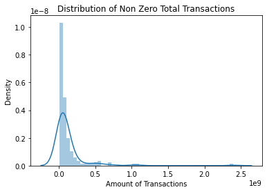

```python
non_zero = temp[temp["totals.transactions"] > 0]["totals.transactions"]
print ("There are " + str(len(non_zero)) + " visitors in the train dataset having transactions")
#
non_zero = temp[temp["totals.totalTransactionRevenue"] > 0]["totals.totalTransactionRevenue"]
print ("There are " + str(len(non_zero)) + " visitors in the train dataset having non zero total transaction revenue")
#plt.figure(figsize=(12,6))
sns.distplot(non_zero)
plt.title("Distribution of Non Zero Total Transactions");
plt.xlabel("Amount of Transactions");
```

Lets take the natural log on the transactions

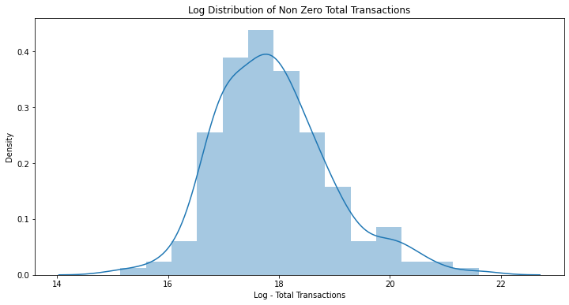

```python
plt.figure(figsize=(12,6))
sns.distplot(np.log1p(non_zero))
plt.title("Log Distribution of Non Zero Total Transactions");
plt.xlabel("Log - Total Transactions");
```

### 3.3 Some Visitor Profile Attributes

```python
def getbin_hits(x):
    if x < 5:
        return "1-5"
    elif x < 10:
        return "5-10"
    elif x < 30:
        return "10-30"
    elif x < 50:
        return "30-50"
    elif x < 100:
        return "50-100"
    else:
        return "100+"

temp["totals.visits_bin"] = temp["totals.visits"].apply(lambda x : str(x) if x <= 5 else "5+")
temp["totals.hits_bin"] = temp["totals.hits"].apply(getbin_hits)
temp["totals.bounces_bin"] = temp["totals.bounces"].apply(lambda x : str(x) if x <= 5 else "5+")
temp["totals.newVisits_bin"] = temp["totals.newVisits"].apply(lambda x : str(x) if x <= 5 else "5+")
temp["totals.pageviews_bin"] = temp["totals.pageviews"].apply(lambda x : str(x) if x <= 50 else "50+")
temp["totals.timeOnSite_bin"] = temp["totals.hits"].apply(lambda x : str(x) if x <= 10 else "10+")
temp["totals.sessionQualityDim_bin"] = temp["totals.hits"].apply(lambda x : str(x) if x <= 20 else "20+")

t1 = temp["totals.visits_bin"].value_counts()
t2 = temp["totals.hits_bin"].value_counts()
t3 = temp["totals.bounces_bin"].value_counts()
t4 = temp["totals.newVisits"].value_counts()
t5 = temp["totals.pageviews_bin"].value_counts()
t6 = temp["totals.timeOnSite_bin"].value_counts()
t7 = temp["totals.sessionQualityDim_bin"].value_counts()


fig = tools.make_subplots(rows=4, cols=2, subplot_titles=["Total Visits per Visitor", "Total Hits per User",
                                                          "Total Bounces", "Total New Visits",
                                                          "Total PageViews per User","Total Time On Site",
                                                          "Total Session Quality Dim"], print_grid=False)

tr1 = go.Bar(x = t1.index[:20], y = t1.values[:20])
tr2 = go.Bar(x = t2.index[:20], y = t2.values[:20])
tr3 = go.Bar(x = t3.index[:20], y = t3.values[:20])
tr4 = go.Bar(x = t4.index, y = t4.values)
tr5 = go.Bar(x = t5.index, y = t5.values)
tr6 = go.Bar(x = t6.index, y = t6.values)
tr7 = go.Bar(x = t7.index, y = t7.values)

fig.append_trace(tr1, 1, 1)
fig.append_trace(tr2, 1, 2)
fig.append_trace(tr3, 2, 1)
fig.append_trace(tr4, 2, 2)
fig.append_trace(tr5, 3, 1)
fig.append_trace(tr6, 3, 2)
fig.append_trace(tr7, 4, 1)
fig['layout'].update(height=700, showlegend=False)
iplot(fig)
```

[interactive chart not shown]

# Question 1

## Choose appropriate metrics to filter out potential purchaser

- Less bounces </br> Potential purchasers may not bounce out right after landing too often , which indicates no interest.
- More hits </br> They are more likely to get involved in interaction events to explore what they need.
- Higher session quality </br> They are also the group more close to transaction.

### Bounces

```python
# total bounces of actual purchasers
non_zero = temp[temp["totals.transactions"] > 0]
non_zero['totals.bounces'].value_counts()
```

```
0.0    329
1.0     15
2.0      2
Name: totals.bounces, dtype: int64
```

- Among 346 actual purchasers, 15 bounce out once, 2 bounce out twice, and the rest has no bounce.

```python
# total bounces of all visitors
temp['totals.bounces'].value_counts()
```

```
0.0    9075
1.0    8114
2.0     427
3.0      55
4.0      15
5.0       2
8.0       1
6.0       1
Name: totals.bounces, dtype: int64
```

- Among 17690 visitors, some of them bounce out more than 3 times.

```python
# Average bounces of actual purchasers
non_zero['avg.bounces'] = non_zero.apply(lambda x: x['totals.bounces']/x['visitNumber'],
                                         axis = 1)
non_zero['avg.bounces'].value_counts().to_frame()\
                       .reset_index().sort_values(by='index')\
                       .rename(columns = {'index':'avg.bounces','avg.bounces':'counts'})
```

|  | avg.bounces | counts |
| --- | --- | --- |
| 0 | 0.000000 | 329 |
| 3 | 0.014815 | 1 |
| 10 | 0.034483 | 1 |
| 5 | 0.047619 | 1 |
| 2 | 0.066667 | 2 |
| 4 | 0.083333 | 1 |
| 9 | 0.111111 | 1 |
| 7 | 0.142857 | 1 |
| 11 | 0.166667 | 1 |
| 8 | 0.200000 | 1 |
| 6 | 0.222222 | 1 |
| 1 | 0.333333 | 6 |

- For actual purchasers, the majority has 0 bounce.
- But there are still tens of them with average bounce range from 0 to 0.33.

```python
# Average bounces of all visitors
temp['avg.bounces'] = temp.apply(lambda x: x['totals.bounces']/x['visitNumber'],
                                         axis = 1)
temp['avg.bounces'].describe().to_frame()
```

|  | avg.bounces |
| --- | --- |
| count | 17690.000000 |
| mean | 0.405269 |
| std | 0.465609 |
| min | 0.000000 |
| 25% | 0.000000 |
| 50% | 0.000000 |
| 75% | 1.000000 |
| max | 1.000000 |

- Among 17690 visitors, one fourth of them have average bounce equals to 1.
- Because bounce indicates no interest, I would not treat visitors with average bounce larger than 0.4 as potential purchaser

### Hits

```python
# Average hits of actual purchasers
non_zero['avg.hits']=non_zero.apply(lambda x: x['totals.hits']/x['visitNumber'],
                                    axis = 1)
non_zero['avg.hits'].describe().to_frame()
```

|  | avg.hits |
| --- | --- |
| count | 346.000000 |
| mean | 16.043863 |
| std | 16.869057 |
| min | 0.121673 |
| 25% | 7.000000 |
| 50% | 12.000000 |
| 75% | 18.000000 |
| max | 178.000000 |

```python
# Average hits of all visitors
temp['avg.hits']=temp.apply(lambda x: x['totals.hits']/x['visitNumber'],
                            axis = 1)
temp['avg.hits'].describe().to_frame()
```

|  | avg.hits |
| --- | --- |
| count | 17690.000000 |
| mean | 4.102623 |
| std | 8.294522 |
| min | 0.005882 |
| 25% | 1.000000 |
| 50% | 1.250000 |
| 75% | 4.000000 |
| max | 500.000000 |

- Hits reflect interaction events carried out by visitors.
- By comparision,we can see actual purchasers have larger average hits on average.
- Although minimum average hit of acutal purchaser is only 0.12, I would not treat visitors with average hits less than 7, that is 25% quantile of actual purchaser, as potential purchaser.

### Session quality

```python
non_zero['avg.sessionQualityDim'] = non_zero.apply(lambda x: x['totals.sessionQualityDim']/x['visitNumber'],
                                                   axis = 1)
non_zero['avg.sessionQualityDim'].describe().to_frame()
```

|  | avg.sessionQualityDim |
| --- | --- |
| count | 346.000000 |
| mean | 43.960612 |
| std | 28.323420 |
| min | 0.422053 |
| 25% | 19.361111 |
| 50% | 38.750000 |
| 75% | 69.000000 |
| max | 96.000000 |

```python
temp['avg.sessionQualityDim'] = temp.apply(lambda x: x['totals.sessionQualityDim']/x['visitNumber'],
                                           axis = 1)
temp['avg.sessionQualityDim'].describe().to_frame()
```

|  | avg.sessionQualityDim |
| --- | --- |
| count | 17690.000000 |
| mean | 3.647295 |
| std | 10.383270 |
| min | 0.003386 |
| 25% | 1.000000 |
| 50% | 1.000000 |
| 75% | 1.000000 |
| max | 96.000000 |

- Session quality can reflect how close a session was to transaction.
- From statistics above,there exists huge gap between actual purchasers and normal visitors when it comes to seesion quality.
- I would not treat visitors with average session quality less than 20, around 25% quantile of actual purchasers, as potential purchasers.

### To conclude, I define visitors below as potential purchasers

Average bounces < 0.4  
Average hits > 7  
Average session quality > 20

### Seperate potential purchasers from train set

```python
id_potential = temp.loc[(temp['avg.bounces'] <0.4) &
                        (temp['avg.hits'] >7.0) &
                        (temp['avg.sessionQualityDim'] >20.0)]['fullVisitorId']

print('Number of potential purchasers: ',
id_potential.shape[0])
```

```
Number of potential purchasers:  735
```

```python
print('Number of non potential purchasers: ',
train['fullVisitorId'].nunique() - id_potential.shape[0])
```

```
Number of non potential purchasers:  16955
```

```python
# seperate potential purchasers from train dataset
purchaser = train[train['fullVisitorId'].isin(id_potential)]
purchaser.shape
```

```
(782, 50)
```

# Question 2

## Persona of potential purchaser

### Device

```python
# columns related to device
device_colname = train.columns[train.columns.str.contains('device')].to_list()
device_colname
```

```
['device.browser',
 'device.browserVersion',
 'device.browserSize',
 'device.operatingSystem',
 'device.operatingSystemVersion',
 'device.isMobile',
 'device.mobileDeviceBranding',
 'device.mobileDeviceModel',
 'device.mobileInputSelector',
 'device.mobileDeviceInfo',
 'device.mobileDeviceMarketingName',
 'device.flashVersion',
 'device.language',
 'device.screenColors',
 'device.screenResolution',
 'device.deviceCategory']
```

```python
print('Number of columns related to device: ',
len(device_colname))
```

```
Number of columns related to device:  16
```

Amone 16 columns related to device, I would only analyze 3 most important ones with information available:

- device.browser
- device.operatingSystem
- device.deviceCategory

```python
device_cols = ["device.deviceCategory", "device.operatingSystem", "device.browser"]

colors = ["#fca6da", "#f4d39c","steelblue"]
traces = []
for i, col in enumerate(device_cols):
    t = purchaser[col].value_counts()
    traces.append(go.Bar(marker=dict(color = colors[i]),
                         orientation = 'h',
                         x = t.values[:15][::-1],
                         y = t.index[:15][::-1]))

fig = tools.make_subplots(rows = 3,cols = 1,
                          subplot_titles = device_cols)
fig.append_trace(traces[0], 1, 1)
fig.append_trace(traces[1], 2, 1)
fig.append_trace(traces[2], 3, 1)

fig['layout'].update(height = 600,
                     width = 600,
                     showlegend = False,
                     title = 'Device attributes of potential purchaser')
iplot(fig)
```

[interactive chart not shown]

- Potential purchasers seldom use mobile device or tablet to purchase.
- The most typical poential purchasers use Chrome on Macintosh to purchase.

### Geo Network

```python
geo_colname = train.columns[train.columns.str.contains('geo')].to_list()
geo_colname
```

```
['geoNetwork.continent',
 'geoNetwork.subContinent',
 'geoNetwork.country',
 'geoNetwork.region',
 'geoNetwork.metro',
 'geoNetwork.city',
 'geoNetwork.cityId',
 'geoNetwork.networkDomain',
 'geoNetwork.latitude',
 'geoNetwork.longitude',
 'geoNetwork.networkLocation']
```

```python
print('Number of columns related to Geo Network: ',
len(geo_colname))
```

```
Number of columns related to Geo Network:  11
```

```python
geo_cols = ['geoNetwork.continent','geoNetwork.subContinent']
colors = ["#fca6da","#f4d39c","steelblue"]

fig2 = tools.make_subplots(rows = 2, cols = 1,
                          subplot_titles = geo_cols,
                          print_grid = False)
trs = []

for i,col in enumerate(geo_cols):
    t = purchaser[col].value_counts()
    tr = go.Bar(x = t.values[:20][::-1],
                y = t.index[:20][::-1],
                orientation = 'h',
                marker = dict(color = colors[i]))
    trs.append(tr)

fig2.append_trace(trs[0],1,1)
fig2.append_trace(trs[1],2,1)
fig2['layout'].update(height = 600,
                     width = 600,
                     showlegend = False,
                     title = 'Geo attribute of potential purchaser')
iplot(fig2)
```

[interactive chart not shown]

```python
tmp1 = purchaser["geoNetwork.country"].value_counts()

colorscale = [[0, 'rgb(102,194,165)'], [0.005, 'rgb(102,194,165)'],
              [0.01, 'rgb(171,221,164)'], [0.02, 'rgb(230,245,152)'],
              [0.04, 'rgb(255,255,191)'], [0.05, 'rgb(254,224,139)'],
              [0.10, 'rgb(253,174,97)'], [0.25, 'rgb(213,62,79)'], [1.0, 'rgb(158,1,66)']]

data = [ dict(type = 'choropleth',
              autocolorscale = False,
              showscale = True,
              locations = tmp1.index,
              z = tmp1.values,
              locationmode = 'country names',
              text = tmp1.values,
              marker = dict(line = dict(color = '#fff', width = 2))) ]

layout = dict(
    height=500,
    title = 'Distribution of potential purchaser by country',
    geo = dict(
        showframe = True,
        showocean = True,
        oceancolor = '#222',
        projection = dict(
        type = 'orthographic',
            rotation = dict(
                    lon = 60,
                    lat = 10),
        ),
        lonaxis =  dict(
                showgrid = False,
                gridcolor = 'rgb(102, 102, 102)'
            ),
        lataxis = dict(
                showgrid = False,
                gridcolor = 'rgb(102, 102, 102)'
                )
            ),
        )
fig = dict(data=data, layout=layout)
iplot(fig)
```

[interactive chart not shown]

```python
c = purchaser["geoNetwork.country"].value_counts()
trace = go.Bar(x = c.values[:18][::-1],
               y = c.index[:18][::-1],
               orientation = 'h',
               marker = dict(color = 'steelblue'))
layout = {'title':'Distribution of potential purchaser by country'}
fig = go.Figure(data = [trace], layout = layout)
iplot(fig)
```

[interactive chart not shown]

- The majority of potential purchaser comes from America.
- Apart from India and Japan, other top countries are mainly west European countries.
- It means western countries consist of the major market.

### Traffic source

```python
# columns related to traffic source
train.columns[train.columns.str.contains('traffic')].to_list()
```

```
['trafficSource.referralPath',
 'trafficSource.campaign',
 'trafficSource.source',
 'trafficSource.medium',
 'trafficSource.keyword',
 'trafficSource.adContent',
 'trafficSource.isTrueDirect',
 'trafficSource.adwordsClickInfo.criteriaParameters']
```

```python
fig = tools.make_subplots(rows=2, cols=1,
                          subplot_titles=["TrafficSource Medium", "TrafficSource Campaign"],
                          print_grid=False)

colors = ["#d6a5ff", "#fca6da"]
t1 = purchaser["trafficSource.medium"].value_counts()
t2 = purchaser["trafficSource.campaign"].value_counts()
tr1 = go.Bar(x = t1.values[::-1], y = t1.index[::-1], orientation = 'h', marker=dict(color=colors[0]))
tr2 = go.Bar(x = t2.values[::-1], y = t2.index[::-1], orientation = 'h', marker=dict(color=colors[1]))

fig.append_trace(tr1, 1, 1)
fig.append_trace(tr2, 2, 1)
fig['layout'].update(height=600,
                     margin=dict(b=100),
                     showlegend=False)
iplot(fig)
```

[interactive chart not shown]

- It's surprising to find that almost all potential purchasers are not attracted by campaign.
- The most used medium is not the typical type. Organic search comes next and accounts for one fourth.
- All signs indicate a good news that potential purchasers are not driven by stimulation, but by true needs.

### Channel

```python
tmp = purchaser["channelGrouping"].value_counts()
colors = ["#8d44fc", "#ed95d5", "#caadf7", "#6161b7", "#7e7eba", "#babad1"]
trace = go.Pie(labels=tmp.index, values=tmp.values, marker=dict(colors=colors))
layout = go.Layout(title="Channel Grouping", height=400)
fig = go.Figure(data = [trace], layout = layout)
iplot(fig)
```

[interactive chart not shown]

- Direct, organic search and referral are 3 major channels.
- Paid search account for a tiny part.
- Findings from channel are consistent with what we have got from traffic source.
- That is, potential purchasers go directly to what they need and are very active.

### Visit by month, monthday, and weekday

```python
def _add_date_features(df):
    df['date'] = df['date'].astype(str)
    df['date'] = df['date'].apply(lambda x: x[:4] + '-' + x[4:6] + '-' + x[6:])
    df['date'] = pd.to_datetime(df['date'])

    df['month'] = df['date'].dt.month
    df['day'] = df['date'].dt.day
    df['weekday'] = df['date'].dt.weekday

    return df

purchaser = _add_date_features(purchaser)

tmp = purchaser['date'].value_counts().to_frame().reset_index().sort_values('index')
tmp = tmp.rename(columns = {'index': 'dateX', 'date': 'visits'})

tr = go.Scatter(mode = 'lines', x = tmp['dateX'].astype(str), y = tmp['visits'])
layout = go.Layout(title = 'Daily visits of potential purchaser', height = 400)
fig = go.Figure(data = [tr], layout = layout)
iplot(fig)
```

[output not shown]

[interactive chart not shown]

```python
fig = tools.make_subplots(rows = 1, cols = 2,
                          subplot_titles = ["By Month", "By WeekDay"],
                          print_grid = False)

colors = ["#ed95d5", "#caadf7"]
trs = []
for i,col in enumerate(['month','weekday']):
    t = purchaser[col].value_counts()
    tr = go.Bar(y = t.values,
                x = t.index,
                marker = dict(color = colors[i]))
    trs.append(tr)

fig.append_trace(trs[0], 1, 1)
fig.append_trace(trs[1], 1, 2)

fig['layout'].update(height = 400,
                     width = 800,
                     showlegend = False,
                     title = 'Visits by potential purchaser')
iplot(fig)
```

[interactive chart not shown]

- Potential purchaser make the most visits on June, but the least on July.
- They also prefer to visit on Sunday, and less on Tuesday and Wednesday.

```python
v = purchaser['visitNumber'].value_counts().to_frame().reset_index()\
                            .rename(columns = {'index':'visitNumber',
                                               'visitNumber':'counts'})

trace = go.Bar(x = v['visitNumber'],y= v['counts'])

layout = dict(
          title='Distribution of potential purchaser by visit frequency',
          xaxis = dict(tickmode = 'array', tickvals = [1,2,3,4])
          )
fig = go.Figure(data = [trace], layout = layout)
iplot(fig)
```

[interactive chart not shown]

- The majority of potential purchasers makes just one visit.

## 4. Data for Modelling

Remember many algorithms only work in numeric and can not run with missing variable, these are two essential step to check on types of variables and eliminate missing variables

There are several important steps to deal with data variables

1. Drop single value variables
2. Deal with missing variables again
3. Drop too many type categorical/object variables
4. Trace out another labels of configuration of nill inputs
5. Create variables from "date" and "time" variables
6. Encode the categorical variables

```python
train.shape
```

```
(20000, 50)
```

### A. Drop single value varaibles

Takeoff all columns where we have a unique value (constants). It is useful because this columns don't give us any information

```python
discovering_consts = [col for col in train.columns if train[col].nunique() == 1]
# printing the total of columns dropped and the name of columns
print("Columns with just one value: ", len(discovering_consts), "columns")
print("Name of constant columns: \n", discovering_consts)
train = train.drop(discovering_consts, axis=1)
```

[output not shown]

### B. Missing Variables

Below is the code chunk found in https://www.kaggle.com/gpreda to deal with "missing variables"

```python
def missing_values(data):
    total = data.isnull().sum().sort_values(ascending = False) # getting the sum of null values and ordering
    percent = (data.isnull().sum() / data.isnull().count() * 100 ).sort_values(ascending = False) #getting the percent and order of null
    df = pd.concat([total, percent], axis=1, keys=['Total', 'Percent']) # Concatenating the total and percent

    print("Total columns at least one missing Values: ")
    print (df[~(df['Total'] == 0)]) # Returning values of nulls different of 0
    #print("\n Total of Sales % of Total: ", round((train[train['totals.transactionRevenue'] != np.nan]['totals.transactionRevenue'].count() / len(df_train['totals.transactionRevenue']) * 100),4))
    return
missing_values(train)
```

```
Total columns at least one missing Values:
                                Total  Percent
totals.totalTransactionRevenue  19821   99.105
totals.transactions             19652   98.260
totals.timeOnSite                9247   46.235
trafficSource.keyword            1845    9.225
totals.pageviews                    4    0.020
```

```python
# Because many of columns above are important, I would replace NA with 0
train['totals.totalTransactionRevenue'].fillna(0,inplace=True)
train["totals.transactions"].fillna(0,inplace=True)
train['totals.timeOnSite'].fillna(0,inplace=True)
train['totals.pageviews'].fillna(0,inplace=True)
```

### C. Drop too many type categorical variables

One may like to focus on small number of types of categorial (or object) variables, so you may like to drop unique value of variables with dimensions more than either 20 or ... or 50

```python
columns = list(train.select_dtypes(include='object')) # category or object
# for col in columns:
#    train[col].nunique()


for col in columns:
        if train[col].nunique() > 20: # number to be determined
             train = train.drop(col, axis=1)
# for col in columns:
columns = list(train.select_dtypes(include='object')) # category or object
```

### D. Trace out another labels of configuration of nill inputs

Setting nill fill variables, closed to the meaning to missing variable)

```python
columns = list(train.select_dtypes(include='object'))
for col in columns:
    print(f"Varaibles name = ", col)
    print(f"Unique Value = ", train[col].unique())
    print(f" ")
```

```
Varaibles name =  channelGrouping
Unique Value =  ['Organic Search' 'Direct' 'Affiliates' 'Referral' 'Paid Search' 'Social'
 'Display' '(Other)']

Varaibles name =  device.browser
Unique Value =  ['Chrome' 'Internet Explorer' 'Safari (in-app)' 'Edge' 'Safari' 'Firefox'
 'YaBrowser' 'Opera' 'Android Webview' 'Opera Mini' 'UC Browser'
 'Samsung Internet' 'Amazon Silk' 'Mozilla Compatible Agent' 'Coc Coc'
 'Maxthon' 'Android Browser' 'Puffin']

Varaibles name =  device.operatingSystem
Unique Value =  ['Android' 'Macintosh' 'Chrome OS' 'iOS' 'Windows' 'Linux' 'Windows Phone'
 'Samsung' 'Tizen' 'BlackBerry' '(not set)' 'OS/2' 'Xbox']

Varaibles name =  device.deviceCategory
Unique Value =  ['mobile' 'desktop' 'tablet']

Varaibles name =  geoNetwork.continent
Unique Value =  ['Asia' 'Americas' 'Europe' 'Oceania' '(not set)' 'Africa']

Varaibles name =  trafficSource.campaign
Unique Value =  ['(not set)' 'Data Share Promo' 'Run of Network Line Item'
 'Page: contains "/google+redesign/drinkware"'
 'Page: contains "/google+redesign/drinkware" Similar Audiences'
 'AW - Accessories' 'Smart Display Campaign'
 '"google + redesign/Accessories March 17" All Users'
 '"google + redesign/Accessories March 17" All Users Similar Audiences'
 '(direct)' 'AW - YouTube Brand' 'AW - Google Brand' 'AW - Bags'
 'AW - Apparel' 'AW - Office' 'AW - Drinkware' 'Technology/Technophiles'
 'AW - Dynamic Search Ads Whole Site' 'AW - Android Brand'
 'AW - Waze Brand']

Varaibles name =  trafficSource.medium
Unique Value =  ['organic' '(none)' 'affiliate' 'referral' 'cpc' 'cpm' '(not set)']

Varaibles name =  trafficSource.adContent
Unique Value =  ['(not set)' 'Google Merchandise Collection'
 'Smart display ad - 8/17/2017' 'BQ' 'YouTube Merchandise Collection'
 'Official Google Merchandise' 'YouTube Apparel Merchandise'
 'Google Office Merchandise' 'Google Apparel Merchandise'
 'YouTube Accessories Collection' 'Official Google Branded Bags'
 'Official Google Drinkware' 'Google Accessories Collection'
 'Android Accessories Collection' 'Android Merchandise Collection'
 'Google Headgear Merchandise' 'Waze Merchandise Collection']
```

Trace out special characters that may affect running the code, repeat the above step and below step until it is done.

```python
for col in columns:
        train[col] = train[col].str.replace("(", "")
        train[col] = train[col].str.replace(")", "")
        train[col].astype('object')
```

```python
for col in columns:
        train[col] = train[col].str.replace("-", " ")
        train[col] = train[col].str.replace("+", " ")
        train[col] = train[col].str.replace("/", " ")
        train[col].astype('object')
```

### E. Drop mix type varaible if exists

```python
# train = train.drop("trafficSource.keyword", axis=1)
# train.shape
```

### F. Create variables from "date" and "time" variables

```python
train['formated_date'] = pd.to_datetime(train['date'], format='%Y%m%d', errors='coerce')
train['year'] = train['formated_date'].apply(lambda x:x.year)
train['month'] = train['formated_date'].apply(lambda x:x.month)
#train['montht'] = train['formated_date'].apply(lambda x:x.day/10)
train['weekday'] = train['formated_date'].apply(lambda x:x.weekday())
```

```python
train['formated_time'] = pd.to_datetime(train['visitStartTime'], unit='s', errors='coerce')
train['time']=pd.to_datetime(train['formated_time'], format='%d-%m-%Y %H:%M:%S.%f', errors='coerce')
train['hr'] = train['formated_time'].apply(lambda x:x.hour)
#train['_min'] = train['formated_time'].apply(lambda x:x.minute)
#train['_sec'] = train['formated_time'].apply(lambda x:x.second)
```

```python
train.drop(['date','time','formated_date','formated_time'], axis=1, inplace=True)
train.astype({'year': 'object','month': 'object','hr':'object','weekday':'object'}).dtypes
```

```
channelGrouping                     object
fullVisitorId                     category
visitNumber                        float64
visitStartTime                       int64
device.browser                      object
device.operatingSystem              object
device.isMobile                       bool
device.deviceCategory               object
geoNetwork.continent                object
totals.hits                        float64
totals.pageviews                   float64
totals.timeOnSite                  float64
totals.sessionQualityDim           float64
totals.transactions                float64
totals.totalTransactionRevenue     float64
trafficSource.campaign              object
trafficSource.medium                object
trafficSource.adContent             object
year                                object
month                               object
weekday                             object
hr                                  object
dtype: object
```

### G. Encode the categorical/object variables

```python
from sklearn import preprocessing
import sklearn.model_selection as ms
from sklearn import linear_model
import sklearn.metrics as sklm
```

```python
columns = list(train.select_dtypes(include='object'))
print(columns)
columns = columns + ['year','month', 'weekday','hr']
predictor = columns
print(predictor)
```

```
['channelGrouping', 'device.browser', 'device.operatingSystem', 'device.deviceCategory', 'geoNetwork.continent', 'trafficSource.campaign', 'trafficSource.medium', 'trafficSource.adContent']
['channelGrouping', 'device.browser', 'device.operatingSystem', 'device.deviceCategory', 'geoNetwork.continent', 'trafficSource.campaign', 'trafficSource.medium', 'trafficSource.adContent', 'year', 'month', 'weekday', 'hr']
```

```python
columns2 = list(train.select_dtypes(include='object'))
print(columns2)
columns2 = columns2 + ['year','month', 'weekday','hr']
predictor2 = columns2
print(predictor2)
```

```
['channelGrouping', 'device.browser', 'device.operatingSystem', 'device.deviceCategory', 'geoNetwork.continent', 'trafficSource.campaign', 'trafficSource.medium', 'trafficSource.adContent']
['channelGrouping', 'device.browser', 'device.operatingSystem', 'device.deviceCategory', 'geoNetwork.continent', 'trafficSource.campaign', 'trafficSource.medium', 'trafficSource.adContent', 'year', 'month', 'weekday', 'hr']
```

```python
def encode_string(cat_features):
    ## First encode the strings to numeric categories
    enc = preprocessing.LabelEncoder()
    enc.fit(cat_features)
    enc_cat_features = enc.transform(cat_features)
    ## Now, apply one hot encoding
    ohe = preprocessing.OneHotEncoder()
    encoded = ohe.fit(enc_cat_features.reshape(-1,1))
    return encoded.transform(enc_cat_features.reshape(-1,1)).toarray()
columns.remove('channelGrouping')
categorical_columns = columns
Features = encode_string(train['channelGrouping'])
for col in categorical_columns:
    print(Features.shape[1],"  ",col)
    temp = encode_string(train[col])
    temp.shape
    Features = np.concatenate([Features, temp], axis = 1)
print(f"Total number of Type Features =", Features.shape[1])
#train = train.drop("channelGrouping", axis=1)
print(Features[1,])
```

```
8    device.browser
26    device.operatingSystem
39    device.deviceCategory
42    geoNetwork.continent
48    trafficSource.campaign
68    trafficSource.medium
75    trafficSource.adContent
92    year
93    month
99    weekday
105    hr
Total number of Type Features = 129
[0. 1. 0. 0. 0. 0. 0. 0. 0. 0. 0. 1. 0. 0. 0. 0. 0. 0. 0. 0. 0. 0. 0. 0.
 0. 0. 0. 0. 0. 0. 1. 0. 0. 0. 0. 0. 0. 0. 0. 1. 0. 0. 0. 1. 0. 0. 0. 0.
 0. 0. 0. 0. 0. 0. 0. 0. 0. 0. 0. 0. 0. 0. 0. 0. 0. 0. 0. 1. 0. 0. 0. 1.
 0. 0. 0. 0. 0. 0. 0. 0. 0. 0. 0. 0. 0. 0. 0. 0. 0. 0. 0. 1. 1. 1. 0. 0.
 0. 0. 0. 0. 0. 0. 1. 0. 0. 0. 0. 0. 0. 0. 0. 0. 0. 0. 0. 0. 0. 0. 0. 0.
 0. 0. 0. 1. 0. 0. 0. 0. 0.]
```

### F. Decide to have classification/regression model to predict whether visitors make transactions

Reinterprete the totals.transactions as {1,0} having transactions or not

```python
train["totals.transactions"]=train["totals.transactions"].fillna(0)
print(train["totals.transactions"][459:530])
train["totals.transactions"] = train['totals.transactions'].replace(2,1)
train["totals.transactions"] = train['totals.transactions'].replace(5,1)
labels = np.array(1-train["totals.transactions"])
print(labels[459:530])
```

```
459    0.0
460    1.0
461    0.0
462    0.0
463    0.0
      ...
525    0.0
526    0.0
527    0.0
528    1.0
529    0.0
Name: totals.transactions, Length: 71, dtype: float64
[1. 0. 1. 1. 1. 1. 0. 1. 0. 1. 0. 0. 1. 1. 1. 1. 1. 1. 1. 1. 1. 1. 1. 1.
 1. 1. 0. 1. 0. 1. 1. 1. 1. 0. 0. 1. 1. 1. 0. 1. 1. 0. 1. 1. 1. 0. 1. 1.
 0. 1. 1. 1. 1. 1. 1. 1. 1. 1. 0. 1. 1. 1. 1. 1. 0. 1. 1. 1. 1. 0. 1.]
```

#### Decide to have regression model to predict how much visitors purchase

```python
# labels = np.array(train["totals.totalTransactionRevenue"])
```

#### By adding numerical variables to the list of categorical variables

```python
columns = ['totals.hits','totals.pageviews',
              'totals.timeOnSite','totals.sessionQualityDim']
predictor = predictor + columns
```

```python
for col in columns:
    train[col] = train[col].fillna(0)
Features = np.concatenate([Features,np.array(train[['totals.hits','totals.pageviews',
              'totals.timeOnSite','totals.sessionQualityDim']])], axis = 1)
print(Features.shape)
print(Features[:2, :])
```

```
(20000, 133)
[[  0.   0.   0.   1.   0.   0.   0.   0.   0.   0.   0.   1.   0.   0.
    0.   0.   0.   0.   0.   0.   0.   0.   0.   0.   0.   0.   1.   0.
    0.   0.   0.   0.   0.   0.   0.   0.   0.   0.   0.   0.   1.   0.
    0.   0.   1.   0.   0.   0.   0.   0.   0.   0.   0.   0.   0.   0.
    0.   0.   0.   0.   0.   0.   0.   0.   0.   0.   0.   1.   0.   0.
    0.   0.   0.   1.   0.   0.   0.   0.   0.   0.   0.   0.   0.   0.
    0.   0.   0.   0.   0.   0.   0.   1.   1.   1.   0.   0.   0.   0.
    0.   0.   0.   0.   1.   0.   0.   0.   0.   0.   0.   1.   0.   0.
    0.   0.   0.   0.   0.   0.   0.   0.   0.   0.   0.   0.   0.   0.
    0.   0.   0.   4.   3. 973.   1.]
 [  0.   1.   0.   0.   0.   0.   0.   0.   0.   0.   0.   1.   0.   0.
    0.   0.   0.   0.   0.   0.   0.   0.   0.   0.   0.   0.   0.   0.
    0.   0.   1.   0.   0.   0.   0.   0.   0.   0.   0.   1.   0.   0.
    0.   1.   0.   0.   0.   0.   0.   0.   0.   0.   0.   0.   0.   0.
    0.   0.   0.   0.   0.   0.   0.   0.   0.   0.   0.   1.   0.   0.
    0.   1.   0.   0.   0.   0.   0.   0.   0.   0.   0.   0.   0.   0.
    0.   0.   0.   0.   0.   0.   0.   1.   1.   1.   0.   0.   0.   0.
    0.   0.   0.   0.   1.   0.   0.   0.   0.   0.   0.   0.   0.   0.
    0.   0.   0.   0.   0.   0.   0.   0.   0.   0.   0.   1.   0.   0.
    0.   0.   0.   4.   3.  49.   1.]]
```

#### Finalise the list of predictor

```python
train.nunique()
#train.dtypes
```

```
channelGrouping                       8
fullVisitorId                     17690
visitNumber                         111
visitStartTime                    19631
device.browser                       18
device.operatingSystem               13
device.isMobile                       2
device.deviceCategory                 3
geoNetwork.continent                  6
totals.hits                          99
totals.pageviews                     77
totals.timeOnSite                  1453
totals.sessionQualityDim             97
totals.transactions                   2
totals.totalTransactionRevenue      163
trafficSource.campaign               20
trafficSource.medium                  7
trafficSource.adContent              17
year                                  1
month                                 6
weekday                               6
hr                                   24
dtype: int64
```

```python
predictor
```

```
['device.browser',
 'device.operatingSystem',
 'device.deviceCategory',
 'geoNetwork.continent',
 'trafficSource.campaign',
 'trafficSource.medium',
 'trafficSource.adContent',
 'year',
 'month',
 'weekday',
 'hr',
 'totals.hits',
 'totals.pageviews',
 'totals.timeOnSite',
 'totals.sessionQualityDim']
```

## 5. Choose 3 Models: Classification Model - WHAT DRIVE THEM TO PURCHASE?

#### Remember to adjust following code to have a satisfactory result

```python
from sklearn.tree import DecisionTreeClassifier
from sklearn.ensemble import RandomForestClassifier, AdaBoostClassifier, GradientBoostingClassifier
from lightgbm import LGBMClassifier
from xgboost import XGBClassifier
from catboost import CatBoostClassifier, Pool
```

```python
import numpy.random as nr
## Randomly sample cases to create independent training and test data
nr.seed(500)
indx = range(Features.shape[0])
indx = ms.train_test_split(indx, test_size = 0.3)
X_train = Features[indx[0],:]
y_train = np.ravel(labels[indx[0]])
X_test = Features[indx[1],:]
y_test = np.ravel(labels[indx[1]])
#
print(X_test.shape)
print(y_test[:100])
print(X_train.shape)
print(y_train[:100])
#
dim_learn = X_train.shape[1]-1
```

```
(6000, 133)
[1. 0. 1. 1. 1. 1. 1. 1. 0. 1. 1. 1. 1. 1. 1. 1. 1. 1. 1. 1. 1. 1. 1. 1.
 1. 1. 1. 1. 1. 1. 1. 1. 1. 1. 1. 1. 1. 1. 1. 1. 1. 1. 1. 1. 1. 1. 1. 1.
 1. 1. 1. 1. 1. 1. 1. 1. 1. 1. 1. 1. 1. 1. 1. 1. 1. 1. 1. 1. 1. 1. 1. 1.
 1. 1. 1. 1. 1. 1. 1. 1. 1. 1. 1. 1. 1. 1. 1. 1. 1. 1. 1. 1. 1. 1. 1. 1.
 1. 1. 1. 1.]
(14000, 133)
[1. 1. 1. 1. 1. 1. 1. 1. 1. 1. 1. 1. 1. 1. 1. 1. 1. 1. 1. 1. 1. 1. 1. 1.
 1. 1. 1. 1. 1. 1. 1. 1. 1. 1. 1. 1. 1. 1. 1. 1. 0. 1. 1. 1. 1. 1. 1. 1.
 1. 1. 1. 1. 1. 1. 1. 1. 1. 1. 1. 1. 1. 1. 1. 1. 1. 1. 1. 1. 1. 1. 1. 1.
 1. 1. 1. 1. 1. 1. 1. 1. 1. 1. 1. 1. 1. 1. 0. 1. 1. 1. 1. 1. 1. 0. 1. 1.
 1. 1. 1. 1.]
```

##### Standard and Scaling all variables

```python
scaler = preprocessing.StandardScaler().fit(X_train[:,dim_learn:])
X_train[:,dim_learn:] = scaler.transform(X_train[:,dim_learn:])
X_test[:,dim_learn:] = scaler.transform(X_test[:,dim_learn:])
#X_train[:2,]
```

### B. Select models

Pick the models applied below is for classificaton, the output of all models is a score value in term of probability of deciding the status fo the classification.

One can choose a more stringent level (the threshold) over 50%, example 60% to determine the conversion rate of the classification model.

```python
# threshold = ???
# algorithm =["LogisticRegression","DecisionTreeClassifier",
#             "RandomForestClassifier", "AdaBoostClassifier", "GradientBoostingClassifier",
#             "LGBMClassifier","XGBClassifier","CatBoostClassifier"]
```

```python
threshold = 0.6
algorithm =[
            "RandomForestClassifier",
            "XGBClassifier",
            "CatBoostClassifier"]
```

#### Logistic Regression

Logisitic Regression is a Machine Learning classification algorithm that is used to predict the probability of a categorical dependent variable. In logistic regression, the dependent variable is a binary variable that contains data coded as 1 (yes, success, etc.) or 0 (no, failure, etc.). In other words, the logistic regression model predicts P(Y=1) as a function of X.

#### Decision Tree Classifier

DecisionTreeClassifier is a class capable of performing multi-class classification on a dataset.

As with other classifiers, DecisionTreeClassifier takes as input two arrays: an array X, sparse or dense, of size [n_samples, n_features] holding the training samples, and an array Y of integer values, size [n_samples], holding the class labels for the training samples:

#### Random Forest Classifier

A random forest is a meta estimator that fits a number of decision tree classifiers on various sub-samples of the dataset and uses averaging to improve the predictive accuracy and control over-fitting. The sub-sample size is always the same as the original input sample size but the samples are drawn with replacement if bootstrap=True (default).

#### Ada Boosting Classifier

Ada-boost or Adaptive Boosting is one of ensemble boosting classifier proposed by Yoav Freund and Robert Schapire in 1996. It combines multiple classifiers to increase the accuracy of classifiers. AdaBoost is an iterative ensemble method. AdaBoost classifier builds a strong classifier by combining multiple poorly performing classifiers so that you will get high accuracy strong classifier. The basic concept behind Adaboost is to set the weights of classifiers and training the data sample in each iteration such that it ensures the accurate predictions of unusual observations. Any machine learning algorithm can be used as base classifier if it accepts weights on the training set. Adaboost should meet two conditions:

The classifier should be trained interactively on various weighed training examples.In each iteration, it tries to provide an excellent fit for these examples by minimizing training error.

#### Gradient Boosting Classifier

Gradient Boosting (GB) is for classification. GB builds an additive model in a forward stage-wise fashion; it allows for the optimization of arbitrary differentiable loss functions. In each stage n*classes* regression trees are fit on the negative gradient of the binomial or multinomial deviance loss function. Binary classification is a special case where only a single regression tree is induced.

#### Light Gradient Boosting Model

LightGBM is a gradient boosting framework that uses tree based learning algorithms. It is designed to be distributed and efficient with the following advantages:

(i) Faster training speed and higher efficiency; (ii) Lower memory usage; (iii) Better accuracy; (iv) Support of parallel and GPU learning; (v) Capable of handling large-scale data.

#### XGB Classifier

XGBoost stands for eXtreme Gradient Boosting.

The name xgboost, though, actually refers to the engineering goal to push the limit of computations resources for boosted tree algorithms. It is an implementation of gradient boosting machines created by Tianqi Chen, now with contributions from many developers. It belongs to a broader collection of tools under the umbrella of the Distributed Machine Learning Community or DMLC who are also the creators of the popular mxnet deep learning library.

XGBoost is a software library that you can download and install on your machine, then access from a variety of interfaces. Its main model features that implement supporting the features of the scikit-learn and R implementations, with new additions like regularization.

Three main forms of gradient boosting are supported:Gradient Boosting algorithm also called gradient boosting machine including the learning rate. Stochastic Gradient Boosting with sub-sampling at the row, column and column per split levels. Regularized Gradient Boosting with both L1 and L2 regularization.

#### CatBoost Algorithm

CatBoost is a state-of-the-art open-source gradient boosting on decision trees library.

Developed by Yandex researchers and engineers, it is the successor of the MatrixNet algorithm that is widely used within the company for ranking tasks, forecasting and making recommendations. It is universal and claimed that: (i)Accurate: leads or ties competition on standard benchmarks; (ii)Robust: reduces the need for extensive hyper-parameter tuning; (iii) Easy-to-use: offers Python interfaces integrated with scikit, as well as R and command-line interfaces; (iv) Practical: uses categorical features directly and scalably; (v)Extensible: allows specifying custom loss functions

```python
def score_model(probs, threshold):
    return np.array([1 if x > threshold else 0 for x in probs[:,1]])

clf = linear_model.LogisticRegression()
clf = clf.fit(X_train, y_train)
proba_model= clf.predict_proba(X_test)
scores = score_model(proba_model, threshold)
print(f"y_test = ", y_test[:10])
print(f"y_predict_probability of", algorithm[0],"model = ", np.array(scores[:10]))

for i in range(1, 4):
    if i == 1:
         clf = RandomForestClassifier()
    if i == 2:
         clf = XGBClassifier()
    if i == 3:
         clf = CatBoostClassifier()
    clf.fit(X_train, y_train)
    #print(f"intercept = ", clf.intercept_, "coefficents = ", clf.coef_)
    temp = clf.predict_proba(X_test)
    #print(temp[:10,:])
    tempscores = score_model(temp, threshold)
    print(f"y_predict_probability of", algorithm[i],"model = ", np.array(tempscores[:10]))
    proba_model = np.concatenate([proba_model, temp], axis = 1)
    scores = np.concatenate([scores, tempscores], axis = 0)
```

```
y_test =  [1. 0. 1. 1. 1. 1. 1. 1. 0. 1.]
y_predict_probability of RandomForestClassifier model =  [1 1 1 1 1 1 1 1 0 1]
y_predict_probability of XGBClassifier model =  [1 1 1 1 1 1 1 1 0 1]
[19:55:31] WARNING: ../src/learner.cc:1061: Starting in XGBoost 1.3.0, the default evaluation metric used with the objective 'binary:logistic' was changed from 'error' to 'logloss'. Explicitly set eval_metric if you'd like to restore the old behavior.
```

[output not shown]

[output cut: 947 more lines]

[output not shown]

[output not shown]

```python
proba_model.shape
```

```
(6000, 6)
```

### C. Evaluation Across models

```python
def print_metrics(labels, scores):
    metrics = sklm.precision_recall_fscore_support(labels, scores)
    conf = sklm.confusion_matrix(labels, scores)
    print('                 Confusion matrix')
    print('                 Score positive    Score negative')
    print('Actual positive    %6d' % conf[0,0] + '             %5d' % conf[0,1])
    print('Actual negative    %6d' % conf[1,0] + '             %5d' % conf[1,1])
    print('Accuracy  %0.2f' % sklm.accuracy_score(labels, scores))
    print(' ')
    print('           Positive      Negative')
    print('Num case   %6d' % metrics[3][0] + '        %6d' % metrics[3][1])
    print('Precision  %6.2f' % metrics[0][0] + '        %6.2f' % metrics[0][1])
    print('Recall     %6.2f' % metrics[1][0] + '        %6.2f' % metrics[1][1])
    print('F1         %6.2f' % metrics[2][0] + '        %6.2f' % metrics[2][1])

#for comparison of algorithms

for i in range(0, 3):
    k = i*6000
    l = (i+1)*6000
    print(f" ", algorithm[i],"model")
    for j in range(0,1):
        tempscores = scores[k:l]
        print_metrics(y_test, tempscores)
        print("")
```

```
  RandomForestClassifier model
                 Confusion matrix
                 Score positive    Score negative
Actual positive        55                47
Actual negative        28              5870
Accuracy  0.99

           Positive      Negative
Num case      102          5898
Precision    0.66          0.99
Recall       0.54          1.00
F1           0.59          0.99

  XGBClassifier model
                 Confusion matrix
                 Score positive    Score negative
Actual positive        51                51
Actual negative        24              5874
Accuracy  0.99

           Positive      Negative
Num case      102          5898
Precision    0.68          0.99
Recall       0.50          1.00
F1           0.58          0.99

  CatBoostClassifier model
                 Confusion matrix
                 Score positive    Score negative
Actual positive        48                54
Actual negative        26              5872
Accuracy  0.99

           Positive      Negative
Num case      102          5898
Precision    0.65          0.99
Recall       0.47          1.00
F1           0.55          0.99
```

```
1
```

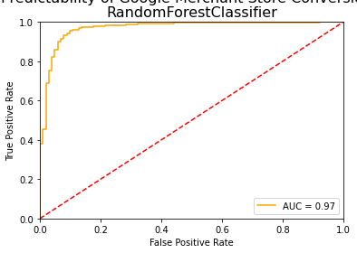

```
3
```

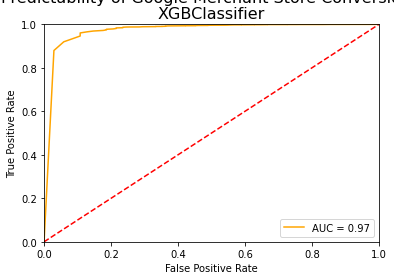

```
5
```

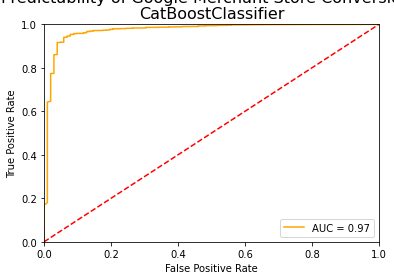

```python
def plot_auc(labels, i):
## Compute the false positive rate, true positive rate
## and threshold along with the AUC
    j = 2*i + 1
    print(j)
    fpr, tpr, threshold = sklm.roc_curve(labels, proba_model[:,j])
    auc = sklm.auc(fpr, tpr)

## Plot the result
    plt.suptitle('Predictability of Google Merchant Store Conversion', y=1, fontsize=16)
    plt.title(algorithm[i], fontsize=16)
    plt.plot(fpr, tpr, color = 'orange', label = 'AUC = %0.2f' % auc)
    plt.legend(loc = 'lower right')
    plt.plot([0, 1], [0, 1],'r--')
    plt.xlim([0, 1])
    plt.ylim([0, 1])
    plt.ylabel('True Positive Rate')
    plt.xlabel('False Positive Rate')
    plt.show()

for i in range(0,3):
    img=plot_auc(y_test, i)
```

Evaluate the model with the likehood to take the decision. The first column is the probability of a score of 0 (converted) and the second column is the probability of a score of 1. Notice that converted is very few cases here.

### Features Importance

#### Predictors: identify number of total features,

Rememner to count features included in the analysis as categorical variables that are treated as "dummy variables" or " individual type categorical efffect" plus the numerical variables. It is also need to notice their order in the estimation.

```python
X_test.shape
```

```
(6000, 133)
```

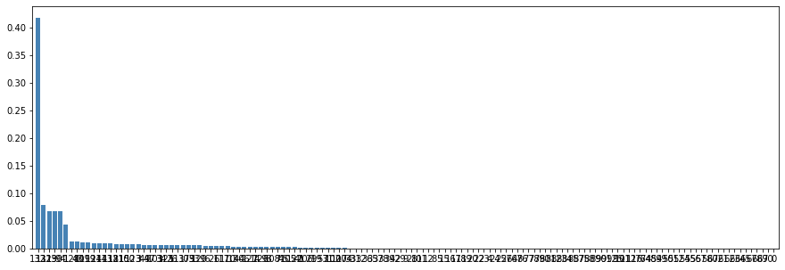

```
(133,)
```

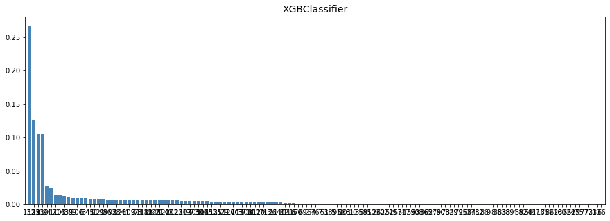

```
(133,)
[20:09:33] WARNING: ../src/learner.cc:1061: Starting in XGBoost 1.3.0, the default evaluation metric used with the objective 'binary:logistic' was changed from 'error' to 'logloss'. Explicitly set eval_metric if you'd like to restore the old behavior.
```

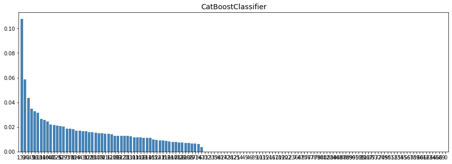

[output not shown]

[output cut: 947 more lines]

[output not shown]

[output not shown]

```python
clf = DecisionTreeClassifier()
clf = clf.fit(X_train, y_train)
temp = clf.feature_importances_
importance = temp
importances = clf.feature_importances_
indices = np.argsort(importances)[::-1]
# X_test is the train data used to test the model
plt.figure(figsize=(15,5))
plt.suptitle('Feature Importance of Google Merchant Store Conversion', y=1, fontsize=16)
# plt.title(algorithm[i], fontsize=14)
# plt.title("Feature importances", algorithm[i])
plt.bar(range(X_test.shape[1]), importances[indices],
          color="steelblue", align="center")
plt.xticks(range(X_test.shape[1]), indices)
plt.xlim([-1, X_test.shape[1]])
plt.show()

for i in range(1, 4):
    print(temp.shape)
    if i == 1:
         clf = RandomForestClassifier()
    if i == 2:
         clf = XGBClassifier()
    if i == 3:
         clf = CatBoostClassifier()
    clf.fit(X_train, y_train)
    temp = clf.feature_importances_
    importance = np.concatenate([importance, temp], axis = 0)
    importances = temp
    tempindex = np.argsort(importances)[::-1]
# X_test is the train data used to test the model
    plt.figure(figsize=(15,5))
    plt.suptitle('Feature Importance of Google Merchant Store Conversion', y=1, fontsize=16)
    plt.title(algorithm[i], fontsize=14)
    plt.bar(range(X_test.shape[1]), importances[tempindex],color="steelblue", align="center")
    plt.xticks(range(X_test.shape[1]), tempindex)
    plt.xlim([-1, X_test.shape[1]])
    plt.show()
    indices = np.concatenate([indices, tempindex], axis = 0)
```

##### All models feature importance data is stored in "importance" according to the predictor list and model order accordingly.

```python
importance_rank=pd.DataFrame({"RandomForestClassifier":indices[0:133],
                              "XGBClassifier":indices[133:266],
                               "CatBoostClassifier":indices[265:398]})
```

```python
# check top 10 important features by 3 models
importance_rank.head(10)
```

|  | RandomForestClassifier | XGBClassifier | CatBoostClassifier |
| --- | --- | --- | --- |
| 0 | 132 | 132 | 66 |
| 1 | 131 | 129 | 132 |
| 2 | 129 | 131 | 94 |
| 3 | 130 | 130 | 1 |
| 4 | 94 | 94 | 43 |
| 5 | 1 | 1 | 96 |
| 6 | 128 | 71 | 113 |
| 7 | 43 | 103 | 104 |
| 8 | 109 | 43 | 118 |
| 9 | 119 | 30 | 100 |

# Question 3

## 5 most important features in purchaser prediction

1.totals.sessionQualityDim </br>

2.totals.timeOnSite </br>

3.totals.hits </br>

4.totals.pageviews </br>

# Question 4

## Suggestion on attracting more potential purchaser

### Factors of action or decision model:

#### Cue

In question 2, we find that most of them were not attracted by campaign. It does not necessarily mean that they would not be stimulated by campaign or ads, but that there are still wide space for campaign and ads to work and improve, such as ads every now and then to raise their awareness for desirable lifestyle.

#### Reaction

Apart from awareness, feeling matters in human decision. We could also associate good feelings with specific products to arouse their needs by precision marketing.

For example, if some of them search for certain dresses very often recently, we could appeal to them by emphasizing that specific dress could make them look younger and more enegetic to help them make an good impression in important occasions, such as recent dating or business negotiation.

#### Evaluation

In question 2, we have already found that most of potential purchasers are very rational and not driven by campaigns too much. We could persuade them by reason to achieve better results.

Take cosmetics as an example, we could emphasize the cost and benefit of products. For example, we could promote medical cosmetics and emphasize its safety. Or just strengthen the impression that the ingredient of cosmetics are rare and nutritious and compare it with competitive products from different dimension.

#### Ability

From question 2, we learn that the majority of potential purchasers use desktop to purchase. It reminds us that we should make shopping on non-mobile device easy and convenient, considering many merchants usually ignore this and invest more resources on mobile users.

We could also assist potential purchasers to make purchase especially when they deal with block trading or are involved in complex deal.

For example, if they are considering buying a computer and can't afford full payment at once, we could provide a lower down-payment for those with good credit score. Or if they are considering buying a up-to-date gadget but are not so experienced in electronic products, we could provide them with experienced technical advisers to make decision process easier.

#### Timing

From question 2, we know that potential purchaser tend to view more pages and linger longer on sites.

If we want to speed up transaction, we could also deliever the message that specific products would go out of stock in certain periods to avoid unnecessary hesitatition.

### Search enginee optimization

There are still a lot of work can be done to make purchasers arrive the site more directly and conveniently. We could make some research on the key search words by this group and imrove **SEO** to their interests.

### User experience

Apart from visitor's side, we could also improve user experience by:

- user-friendly landing page, such as less recommendation of not interested content
- structured design to draw attention
- simplified navigation system to help visitors get what they need more efficiently

THE END